# 03c_REI

J Andres Gannon, Erik Gartzke, and Jon Lindsay, Center for Peace and Security Studies (cPASS)

2020-09-29

This document will look at coverage of Russian electoral inference (1991-2017) from Casey and Ahmad (2017) and identify variables of interest. This is the third of 3 prior datasets used to determine the universe of cases.

The cyber data comes from Casey, Adam; Way, Lucan Ahmad, 2017, “Russian Electoral Interventions, 1991-2017”, https://doi.org/10.5683/SP/BYRQQS, Scholars Portal Dataverse

# 1 Preparation

## 1.1 Load packages

Pipe operators have trouble loading for individual commands

```r
library(magrittr)
library(ggplot2)
```

## 1.2 Load data

File is loaded from inst/ext where external data files are stored

```r
# Load data
load(paste0(here::here(), '/inst/extdata/russian_electoral_interventions_1991-2017.RData'))
rei <- x

incident_count <- nrow(rei)
```

There are 27 DCID incidents in which Russia was an actor.

# 2 Summary statistics

## 2.1 Choose variables

Identify variables of interest regarding the means employed, intensity of crises, etc. These variables are all recoded, but their raw values for those that are not obvious are as follows:

```r
names(rei)
```

```
##  [1] "year"              "target_state"      "target_ccode"
##  [4] "target_event"      "event_sdate"       "event_edate"
##  [7] "pro_incumbent"     "disinfo"           "coup"
## [10] "cyberattack"       "mat_support"       "outcome"
## [13] "outcome_favorable" "rus_impact"
```

```r
# Rename variables for readability
rei <- rei %>% dplyr::rename(
  "Year" = year,
  "Target" = target_state,
  "Target COW code" = target_ccode,
  "Target Event" = target_event,
  "Start Date" = event_sdate,
  "End Date" = event_edate,
  "Pro-incumbent" = pro_incumbent,
  "Disinformation campaign" = disinfo,
  "Coup attempt" = coup,
  "Cyberattack" = cyberattack,
  "Material support" = mat_support,
  "Outcome" = outcome,
  "Favorable outcome" = outcome_favorable,
  "Evidence of impact" = rus_impact
)

# Recode some variables to be more intuitive
rei$`Target Event` <- as.character(rei$`Target Event`)
rei$`Target Event` <- plyr::revalue(rei$`Target Event`, c(
  "1" = "National Election",
  "2" = "Referendum",
  "3" = "Political Party Operations"
))

rei$Outcome <- as.character(rei$Outcome)
rei$Outcome <- plyr::revalue(rei$Outcome, c(
  "1" = "Incumbent victory",
  "2" = "Incumbent loss",
  "3" = "Referendum failure",
  "4" = "Referendum success"
))
```

## 2.2 Summary

Make a table summarizing the data on Russian crisis participation

```r
formattable::formattable(rei,
  align = c("c", "l", "l", "c", "c", "c", "c", "c", "c", "c", "c", "c", "c", "c"),
  list(
    "Pro-incumbent" = formattable::color_tile("transparent", "red"),
    "Disinformation campaign" = formattable::color_tile("transparent", "red"),
    "Coup attempt" = formattable::color_tile("transparent", "red"),
    "Cyberattack" = formattable::color_tile("transparent", "red"),
    "Material support" = formattable::color_tile("transparent", "red"),
    "Favorable outcome" = formattable::color_tile("transparent", "lightblue"),
    "Evidence of impact" = formattable::color_tile("transparent", "lightblue")
  )
)
```

| Year | Target | Target COW code | Target Event | Start Date | End Date | Pro-incumbent | Disinformation campaign | Coup attempt | Cyberattack | Material support | Outcome | Favorable outcome | Evidence of impact |
| --- | --- | --- | --- | --- | --- | --- | --- | --- | --- | --- | --- | --- | --- |
| 2017 | Czech Republic | 316 | National Election | 10/20/2017 | 10/21/2017 | 0 | 1 | 0 | 1 | 0 | Incumbent loss | 2 | 0 |
| 2017 | France | 220 | National Election | 4/23/2017 | 5/7/2017 | 0 | 1 | 0 | 1 | 1 | Incumbent victory | 1 | 1 |
| 2017 | Germany | 255 | National Election | 11/24/2017 | 11/24/2017 | 0 | 1 | 0 | 1 | 0 | Incumbent victory | 1 | 1 |
| 2017 | Malta | 338 | National Election | 6/3/2017 | 6/3/2017 | 0 | 0 | 0 | 1 | 0 | Incumbent victory | 0 | 0 |
| 2017 | Netherlands | 210 | National Election | 3/15/2017 | 3/15/2017 | 0 | 1 | 0 | 0 | 0 | Incumbent victory | 1 | 0 |
| 2017 | Spain | 230 | Referendum | 10/1/2017 | 10/1/2017 | 0 | 1 | 0 | 0 | 0 | Referendum success | 0 | 0 |
| 2016 | Austria | 305 | National Election | 4/24/2016 | 4/24/2016 | 0 | 0 | 0 | 1 | 1 | Incumbent victory | 1 | 0 |
| 2016 | Bulgaria | 355 | National Election | 11/6/2016 | 11/6/2016 | 0 | 1 | 0 | 1 | 0 | Incumbent loss | 1 | 1 |
| 2016 | Italy | 325 | Referendum | 12/4/2016 | 12/4/2016 | 0 | 1 | 0 | 0 | 1 | Referendum failure | 0 | 0 |
| 2016 | Montenegro | 341 | National Election | 10/16/2016 | 10/16/2016 | 0 | 0 | 1 | 1 | 0 | Incumbent victory | 0 | 0 |
| 2016 | Norway | 385 | Political Party Operations | NA | NA | 0 | 0 | 0 | 1 | 0 | NA | 0 | 0 |
| 2016 | Netherlands | 210 | Referendum | 4/6/2016 | 4/6/2016 | 0 | 1 | 0 | 0 | 0 | Referendum failure | 1 | 1 |
| 2016 | United Kingdom | 200 | Referendum | 6/26/2016 | 6/26/2016 | 0 | 1 | 0 | 0 | 0 | Referendum success | 2 | 0 |
| 2016 | United States | 2 | National Election | 11/8/2016 | 11/8/2016 | 0 | 1 | 0 | 1 | 0 | Incumbent loss | 1 | 1 |
| 2015 | Germany | 255 | Political Party Operations | NA | NA | 0 | 0 | 0 | 1 | 0 | NA | 0 | 0 |
| 2015 | United Kingdom | 200 | National Election | 5/7/2015 | 5/7/2015 | 0 | 1 | 0 | 0 | 0 | Incumbent victory | 0 | 0 |
| 2014 | Moldova | 359 | National Election | 11/30/2014 | 11/30/2014 | 0 | 0 | 0 | 0 | 1 | Incumbent victory | 0 | 0 |
| 2014 | Ukraine | 369 | National Election | 5/24/2014 | 5/24/2014 | 0 | 1 | 0 | 1 | 0 | Incumbent victory | 0 | 0 |
| 2010 | Ukraine | 369 | National Election | 1/17/2010 | 2/14/2010 | 0 | 0 | 0 | 0 | 1 | Incumbent loss | 2 | 0 |
| 2009 | Moldova | 359 | National Election | 4/5/2009 | 4/5/2009 | 1 | 0 | 0 | 0 | 1 | Incumbent loss | 0 | 0 |
| 2006 | Belarus | 370 | National Election | 5/19/2006 | 5/19/2006 | 1 | 0 | 0 | 0 | 1 | Incumbent victory | 2 | 0 |
| 2005 | Moldova | 359 | National Election | 3/6/2005 | 3/6/2005 | 0 | 0 | 0 | 0 | 1 | Incumbent victory | 0 | 0 |
| 2004 | Ukraine | 369 | National Election | 10/31/2004 | 12/26/2004 | 1 | 0 | 0 | 0 | 1 | Incumbent loss | 0 | 0 |
| 2002 | Ukraine | 369 | National Election | 3/31/2002 | 3/31/2002 | 1 | 0 | 0 | 0 | 1 | Incumbent loss | 0 | 0 |
| 1996 | Moldova | 359 | National Election | 11/17/1996 | 11/17/1996 | 0 | 0 | 0 | 0 | 1 | Incumbent loss | 2 | 0 |
| 1994 | Belarus | 370 | National Election | 6/23/1994 | 6/23/1994 | 1 | 0 | 0 | 0 | 1 | Incumbent loss | 0 | 0 |
| 1994 | Ukraine | 369 | National Election | 6/26/1994 | 6/26/1994 | 0 | 0 | 0 | 0 | 1 | Incumbent loss | 2 | 1 |

## 2.3 Composite severity variable

There is no variable that directly codes the severity of Russian interference to allow for inter-case comparison.

## 2.4 Plots

Given the number of cases, summarize them in plot format.

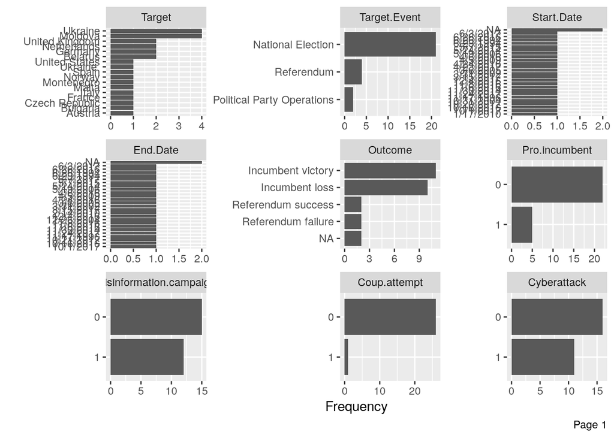

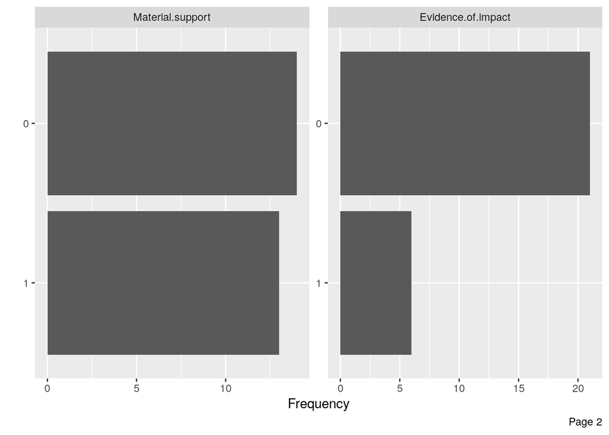

```r
DataExplorer::plot_bar(rei)
```

# 3 Save final dataframe

```r
saveRDS(rei, paste0(here::here(), "/data/","grayzone_rei.rds"))
```